# Final Project 2: Gene Expression ML on TCGA-BRCA

Sihang Jiang

2026-03-26

```r
knitr::opts_chunk$set(echo = TRUE, warning = FALSE, message = FALSE)
set.seed(550)
source("code/00_prepare_analysis_data.R")
```

# 1 Introduction

Breast cancer is a heterogeneous disease with substantial variation in gene expression patterns across patients. High-dimensional transcriptomic data provide an opportunity to identify latent sample structure and to explore potential molecular subgroups using machine learning methods.

The goal of this project is to analyze TCGA-BRCA gene expression data using both unsupervised and supervised learning approaches. Specifically, this analysis uses principal component analysis (PCA) for dimension reduction, k-means clustering for subgroup identification, and LASSO logistic regression for subgroup prediction and feature selection.

## 1.1 Data

The data come from the TCGA breast cancer (BRCA) cohort and consist of normalized RNA-seq gene expression measurements. The analysis begins with a gene-by-sample expression matrix obtained from the curatedTCGAData package.

```r
dim(expr)
```

```
## [1] 395 100
```

## 1.2 Methods

Variance filtering

```r
length(top_genes)
```

```
## [1] 395
```

```r
dim(X)
```

```
## [1] 100 395
```

Here, X is the sample-by-gene matrix used for PCA, clustering, and classification.

Principal component analysis

Principal component analysis was applied to the filtered expression matrix in order to summarize the major axes of variation in the data. The first few principal components were then used as lower-dimensional representations of the samples.

## 1.3 K-means clustering

K-means clustering with 𝑘=2 was applied to the first five principal components. This produced two clusters, which were treated as intrinsic gene-expression subgroups for the remainder of the analysis.

```r
table(y)
```

```
## y
## Cluster 1 Cluster 2
##        22        78
```

After cluster membership was defined, a LASSO logistic regression model was fit using the filtered gene expression matrix as predictors and cluster label as the binary outcome. The purpose of this step was both prediction and variable selection. LASSO imposes an L1 penalty, encouraging sparse solutions and identifying a smaller subset of genes that best distinguish the two clusters.

## 1.4 Results

### 1.4.1 Figure 1: PCA visualization

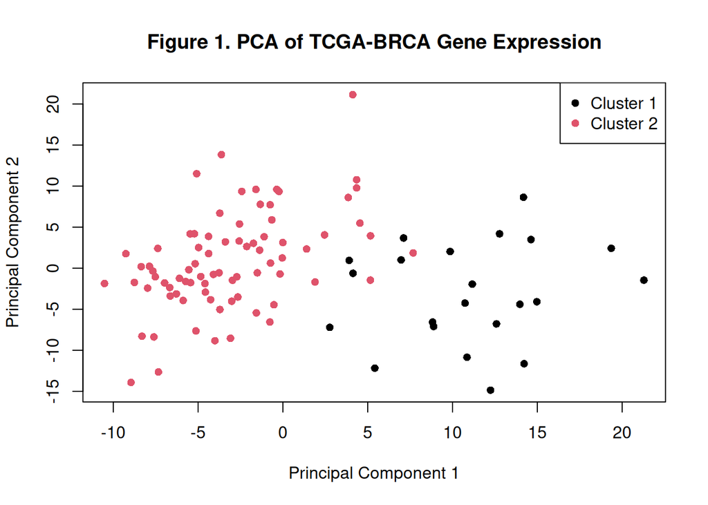

Figure 1 displays the samples projected onto the first two principal components, with points colored by the cluster labels from k-means clustering. The plot suggests that the two clusters occupy partially distinct regions in the reduced-dimensional space, indicating meaningful heterogeneity in the underlying gene expression profiles.

### 1.4.2 Table 1: Genes selected by LASSO

Table 1. Top Genes Selected by LASSO

Non-zero coefficients at lambda.1se

| Gene | Coefficient |
| --- | --- |
| AGR2 | 0.2323 |
| AKR7A3 | 0.0008 |
| ADAMTS15 | 0.2564 |
| ACOX2 | 0.0575 |
| ABLIM3 | 0.3452 |
| AADAT | −0.0233 |
| ACADSB | 0.0036 |
| ALCAM | 0.0449 |
| ACOT4 | 0.3028 |
| ADORA3 | 0.0408 |
| ADCY9 | 0.2675 |
| ACTR3B | −0.3287 |
| ABCA2 | 0.0876 |
| AKIRIN2 | −0.7284 |
| ABI1 | −0.1931 |

Table 1 reports genes with non-zero coefficients selected by the LASSO model. These genes represent the strongest contributors to separation between the two inferred expression-based subgroups.

## 1.5 Discussion

Overall, the results show that high-dimensional breast cancer gene expression data contain structured variation that can be summarized and modeled effectively using standard machine learning methods. The PCA plot suggests separation between clusters, while the LASSO model identifies a sparse set of potentially informative genes.

Several limitations should be noted. First, the clusters were defined by an unsupervised algorithm and may not correspond directly to known biological subtypes. Second, the analysis used only one filtering strategy and one clustering specification. Future work could compare alternative clustering methods, incorporate known subtype labels, and evaluate model stability using resampling or external validation.

## 1.6 Conclusion

In summary, this analysis demonstrates a reproducible workflow for exploring TCGA-BRCA transcriptomic data using dimension reduction, clustering, and penalized regression. The project highlights how unsupervised and supervised learning can be combined to identify structure in high-dimensional genomic data and to select genes associated with that structure.